| **Student ID Number and Name** | 127559 Joseph Kamau Watunu |
| --- | --- |
| **Group** | C |
| **Course Code** | BBT4206 |
| **Course Name** | Business Intelligence II |
| **Program** | Bachelor of Business Information Technology |
| **Semester Duration** | 16<sup>th</sup> October 2023 to 28<sup>th</sup> November 2023 \| |

# Dataset

#30000 spotify songs from Joakin Arvidsson on Kaggle. #data source: https://www.kaggle.com/datasets/joebeachcapital/30000-spotify-songs

# Description

The data this week comes from Spotify via the spotifyr package. Charlie Thompson, Josiah Parry, Donal Phipps, and Tom Wolff authored this package to make it easier to get either your own data or general metadata arounds songs from Spotify’s API. Make sure to check out the spotifyr package website to see how you can collect your own data!

# Training vs Test data

We will train and test the model in the ratio 70:30 train:test

# Attributes of the dataset

As provided on Kaggle: variable class description track_id character Song unique ID track_name character Song Name track_artist character Song Artist track_popularity double Song Popularity (0-100) where higher is better track_album_id character Album unique ID track_album_name character Song album name track_album_release_date character Date when album released playlist_name character Name of playlist –> playlist_id character Playlist ID –> playlist_genre character Playlist genre –> playlist_subgenre character Playlist subgenre –> danceability double Danceability describes how suitable a track is for dancing based on a combination of musical elements including tempo, rhythm stability, beat strength, and overall regularity. A value of 0.0 is least danceable and 1.0 is most danceable. –> energy double Energy is a measure from 0.0 to 1.0 and represents a perceptual measure of intensity and activity. Typically, energetic tracks feel fast, loud, and noisy. For example, death metal has high energy, while a Bach prelude scores low on the scale. Perceptual features contributing to this attribute include dynamic range, perceived loudness, timbre, onset rate, and general entropy. –> key double The estimated overall key of the track. Integers map to pitches using standard Pitch Class notation . E.g. 0 = C, 1 = C♯/D♭, 2 = D, and so on. If no key was detected, the value is -1. –> loudness double The overall loudness of a track in decibels (dB). Loudness values are averaged across the entire track and are useful for comparing relative loudness of tracks. Loudness is the quality of a sound that is the primary psychological correlate of physical strength (amplitude). Values typical range between -60 and 0 db. –> mode double Mode indicates the modality (major or minor) of a track, the type of scale from which its melodic content is derived. Major is represented by 1 and minor is 0. –> speechiness double Speechiness detects the presence of spoken words in a track. The more exclusively speech-like the recording (e.g. talk show, audio book, poetry), the closer to 1.0 the attribute value. Values above 0.66 describe tracks that are probably made entirely of spoken words. Values between 0.33 and 0.66 describe tracks that may contain both music and speech, either in sections or layered, including such cases as rap music. Values below 0.33 most likely represent music and other non-speech-like tracks. –> acousticness double A confidence measure from 0.0 to 1.0 of whether the track is acoustic. 1.0 represents high confidence the track is acoustic. instrumentalness double Predicts whether a track contains no vocals. “Ooh” and “aah” sounds are treated as instrumental in this context. Rap or spoken word tracks are clearly “vocal”. The closer the instrumentalness value is to 1.0, the greater likelihood the track contains no vocal content. Values above 0.5 are intended to represent instrumental tracks, but confidence is higher as the value approaches 1.0. liveness double Detects the presence of an audience in the recording. Higher liveness values represent an increased probability that the track was performed live. A value above 0.8 provides strong likelihood that the track is live. valence double A measure from 0.0 to 1.0 describing the musical positiveness conveyed by a track. Tracks with high valence sound more positive (e.g. happy, cheerful, euphoric), while tracks with low valence sound more negative (e.g. sad, depressed, angry). tempo double The overall estimated tempo of a track in beats per minute (BPM). In musical terminology, tempo is the speed or pace of a given piece and derives directly from the average beat duration. duration_ms double Duration of song in milliseconds

First we load the dataset

```r
library(readr)
library(dplyr)
spotify_sampled_data<-read_csv(
  "data/spotify_songs.csv",
  col_types = cols(
    track_id = col_character(),
    track_name = col_character(),
    track_artist = col_character(),
    track_popularity = col_double(),
    track_album_id = col_character(),
    track_album_name = col_character(),
    track_album_release_date = col_character(),
    playlist_name = col_character(),
    playlist_id = col_character(),
    playlist_genre = col_factor(levels = c("edm", "pop","latin","r&b", "rap","rock")),
    playlist_subgenre = col_character(),
    danceability = col_double(),
    energy = col_double(),
    key = col_double(),
    loudness = col_double(),
    mode = col_factor(levels= c("0", "1")),
    speechiness = col_double(),
    acousticness = col_double(),
    instrumentalness = col_double(),
    liveness = col_double(),
    valence = col_double(),
    tempo = col_double(),
    duration_ms = col_double()
  )
)
```

```r
spotify_sampled_data <- spotify_sampled_data %>%
  sample_n(10000)


View(spotify_sampled_data)

dim(spotify_sampled_data)
```

```
## [1] 10000    23
```

We will now Identify the data types in the datatset. ThiS will help us choose the most efficient visualization types and algorithms that we can use.

```r
sapply(spotify_sampled_data, class)
```

```
##                 track_id               track_name             track_artist
##              "character"              "character"              "character"
##         track_popularity           track_album_id         track_album_name
##                "numeric"              "character"              "character"
## track_album_release_date            playlist_name              playlist_id
##              "character"              "character"              "character"
##           playlist_genre        playlist_subgenre             danceability
##                 "factor"              "character"                "numeric"
##                   energy                      key                 loudness
##                "numeric"                "numeric"                "numeric"
##                     mode              speechiness             acousticness
##                 "factor"                "numeric"                "numeric"
##         instrumentalness                 liveness                  valence
##                "numeric"                "numeric"                "numeric"
##                    tempo              duration_ms
##                "numeric"                "numeric"
```

Now we will perform descriptive statistics.

# 1.Measure of frequency.

Here we will try to understand number of instances that belong to each class.

```r
song_data_genre_freq<- spotify_sampled_data$playlist_genre
cbind(frequency=table(song_data_genre_freq),
      percentage=prop.table(table(song_data_genre_freq))*100)
```

```
##       frequency percentage
## edm        1822      18.22
## pop        1661      16.61
## latin      1550      15.50
## r&b        1638      16.38
## rap        1761      17.61
## rock       1568      15.68
```

```r
song_data_mode_freq <- spotify_sampled_data$mode
cbind(frequency=table(song_data_mode_freq),
                 percentage=prop.table(table(song_data_mode_freq))*100)
```

```
##   frequency percentage
## 0      4320       43.2
## 1      5680       56.8
```

```r
song_data_subgenre_freq <- spotify_sampled_data$playlist_subgenre
cbind(frequency=table(song_data_subgenre_freq),
      percentage=prop.table(table(song_data_subgenre_freq))*100)
```

```
##                           frequency percentage
## album rock                      333       3.33
## big room                        335       3.35
## classic rock                    387       3.87
## dance pop                       378       3.78
## electro house                   479       4.79
## electropop                      419       4.19
## gangster rap                    469       4.69
## hard rock                       478       4.78
## hip hop                         397       3.97
## hip pop                         392       3.92
## indie poptimism                 502       5.02
## latin hip hop                   493       4.93
## latin pop                       365       3.65
## neo soul                        505       5.05
## new jack swing                  336       3.36
## permanent wave                  370       3.70
## pop edm                         454       4.54
## post-teen pop                   362       3.62
## progressive electro house       554       5.54
## reggaeton                       304       3.04
## southern hip hop                522       5.22
## trap                            373       3.73
## tropical                        388       3.88
## urban contemporary              405       4.05
```

# Calculating the mode

```r
song_data_genre_mode <- names(table(spotify_sampled_data$playlist_genre))[
  which(table(spotify_sampled_data$playlist_genre)==max(table(spotify_sampled_data$playlist_genre)))
]
print(song_data_genre_mode)
```

```
## [1] "edm"
```

```r
song_data_subgenre_mode <- names(table(spotify_sampled_data$playlist_subgenre))[
  which(table(spotify_sampled_data$playlist_subgenre)==max(table(spotify_sampled_data$playlist_subgenre)))
]
print(song_data_subgenre_mode)
```

```
## [1] "progressive electro house"
```

```r
song_playlistname_mode <- names(table(spotify_sampled_data$playlist_name))[
  which(table(spotify_sampled_data$playlist_name)==max(table(spotify_sampled_data$playlist_name)))
]
print(song_playlistname_mode)
```

```
## [1] "Indie Poptimism"
```

# Measuring the distribution of the data for each variable

```r
summary(spotify_sampled_data)
```

```
##    track_id          track_name        track_artist       track_popularity
##  Length:10000       Length:10000       Length:10000       Min.   : 0.00
##  Class :character   Class :character   Class :character   1st Qu.:24.00
##  Mode  :character   Mode  :character   Mode  :character   Median :45.00
##                                                           Mean   :42.58
##                                                           3rd Qu.:62.00
##                                                           Max.   :99.00
##  track_album_id     track_album_name   track_album_release_date
##  Length:10000       Length:10000       Length:10000
##  Class :character   Class :character   Class :character
##  Mode  :character   Mode  :character   Mode  :character
##
##
##
##  playlist_name      playlist_id        playlist_genre playlist_subgenre
##  Length:10000       Length:10000       edm  :1822     Length:10000
##  Class :character   Class :character   pop  :1661     Class :character
##  Mode  :character   Mode  :character   latin:1550     Mode  :character
##                                        r&b  :1638
##                                        rap  :1761
##                                        rock :1568
##   danceability        energy             key            loudness       mode
##  Min.   :0.0000   Min.   :0.00814   Min.   : 0.000   Min.   :-34.283   0:4320
##  1st Qu.:0.5590   1st Qu.:0.58300   1st Qu.: 2.000   1st Qu.: -8.188   1:5680
##  Median :0.6690   Median :0.72100   Median : 6.000   Median : -6.168
##  Mean   :0.6535   Mean   :0.69890   Mean   : 5.385   Mean   : -6.752
##  3rd Qu.:0.7590   3rd Qu.:0.83900   3rd Qu.: 8.000   3rd Qu.: -4.682
##  Max.   :0.9830   Max.   :1.00000   Max.   :11.000   Max.   :  1.135
##   speechiness      acousticness     instrumentalness       liveness
##  Min.   :0.0000   Min.   :0.00000   Min.   :0.0000000   Min.   :0.0000
##  1st Qu.:0.0412   1st Qu.:0.01510   1st Qu.:0.0000000   1st Qu.:0.0932
##  Median :0.0638   Median :0.07665   Median :0.0000149   Median :0.1290
##  Mean   :0.1082   Mean   :0.17009   Mean   :0.0799010   Mean   :0.1936
##  3rd Qu.:0.1360   3rd Qu.:0.24400   3rd Qu.:0.0037825   3rd Qu.:0.2512
##  Max.   :0.8770   Max.   :0.98600   Max.   :0.9940000   Max.   :0.9960
##     valence          tempo         duration_ms
##  Min.   :0.000   Min.   :  0.00   Min.   :  4000
##  1st Qu.:0.330   1st Qu.: 99.25   1st Qu.:187793
##  Median :0.513   Median :121.48   Median :216116
##  Mean   :0.510   Mean   :120.60   Mean   :225518
##  3rd Qu.:0.694   3rd Qu.:133.03   3rd Qu.:253333
##  Max.   :0.985   Max.   :214.05   Max.   :516893
```

# Measuring the standard deviation of each variable

Important point to note is Low variability is ideal because it means that you can predict information about the population based on sample data. High variability means that the values are less consistent, thus making it harder to make predictions.

```r
sapply(spotify_sampled_data[, c(4,12,13,14,15,17,18,19,20,21,22,23)], class)
```

```
## track_popularity     danceability           energy              key
##        "numeric"        "numeric"        "numeric"        "numeric"
##         loudness      speechiness     acousticness instrumentalness
##        "numeric"        "numeric"        "numeric"        "numeric"
##         liveness          valence            tempo      duration_ms
##        "numeric"        "numeric"        "numeric"        "numeric"
```

```r
sapply(spotify_sampled_data[, c(4,12,13,14,15,17,18,19,20,21,22,23)], sd)
```

```
## track_popularity     danceability           energy              key
##     2.502277e+01     1.450626e-01     1.799915e-01     3.598871e+00
##         loudness      speechiness     acousticness instrumentalness
##     2.988857e+00     1.013024e-01     2.157667e-01     2.169462e-01
##         liveness          valence            tempo      duration_ms
##     1.586805e-01     2.313135e-01     2.691433e+01     5.945902e+04
```

# Meassuring the variance of each variable

```r
sapply(spotify_sampled_data[, c(4,12,13,14,15,17,18,19,20,21,22,23)], var)
```

```
## track_popularity     danceability           energy              key
##     6.261389e+02     2.104315e-02     3.239695e-02     1.295187e+01
##         loudness      speechiness     acousticness instrumentalness
##     8.933266e+00     1.026218e-02     4.655529e-02     4.706567e-02
##         liveness          valence            tempo      duration_ms
##     2.517949e-02     5.350594e-02     7.243812e+02     3.535375e+09
```

# Measuring the Kurtosis of each variable

Kurtosis informs you of how often outliers occur in the results

First we will install the necessary packages

```r
if (!is.element("e1071", installed.packages()[, 1])) {
  install.packages("e1071", dependencies = TRUE)
}
require("e1071")
sapply(spotify_sampled_data[, c(4,12,13,14,15,17,18,19,20,21,22,23)], kurtosis, type=2)
```

```
## track_popularity     danceability           energy              key
##     -0.935184036     -0.053039650      0.006382391     -1.291455139
##         loudness      speechiness     acousticness instrumentalness
##      3.016999816      3.967078180      2.174726906      6.942946765
##         liveness          valence            tempo      duration_ms
##      4.830435122     -0.910290766      0.065006153      2.789564375
```

# Measuring the skewness of each variable

```r
sapply(spotify_sampled_data[, c(4,12,13,14,15,17,18,19,20,21,22,23)], skewness, type=2)
```

```
## track_popularity     danceability           energy              key
##      -0.24303133      -0.46216328      -0.62946670      -0.03103517
##         loudness      speechiness     acousticness instrumentalness
##      -1.27190569       1.91232422       1.66168573       2.86688811
##         liveness          valence            tempo      duration_ms
##       2.05883569      -0.01842560       0.53104430       1.13680205
```

# Measuring the relationships

```r
songs_data_cov <- cov(spotify_sampled_data[, c(4,12,13,14,15,17,18,19,20,21,22,23)])
View(songs_data_cov)
```

# Measuring correlation between variables

```r
song_data_cor <- cor(spotify_sampled_data[,c(4,12,13,14,15,17,18,19,20,21,22,23)])
View(song_data_cor)
```

# One way ANOVA to see if there are significant differences in the means of track popularity across different genres

```r
song_data_oneway_anova <- aov(track_popularity ~ playlist_genre, data = spotify_sampled_data)
summary(song_data_oneway_anova)
```

```
##                  Df  Sum Sq Mean Sq F value Pr(>F)
## playlist_genre    5  185499   37100   61.03 <2e-16 ***
## Residuals      9994 6075264     608
## ---
## Signif. codes:  0 '***' 0.001 '**' 0.01 '*' 0.05 '.' 0.1 ' ' 1
```

# Two-way ANOVA to test the impact of both playlist genre and playlist subgenre on danceability of a song

```r
song_data_twoway_anova<- aov(danceability ~ playlist_genre* playlist_subgenre, data= spotify_sampled_data)
summary(song_data_twoway_anova)
```

```
##                     Df Sum Sq Mean Sq F value Pr(>F)
## playlist_genre       5  44.04   8.808  545.36 <2e-16 ***
## playlist_subgenre   18   5.25   0.292   18.07 <2e-16 ***
## Residuals         9976 161.12   0.016
## ---
## Signif. codes:  0 '***' 0.001 '**' 0.01 '*' 0.05 '.' 0.1 ' ' 1
```

# Two-way ANOVA to test the impact of both playlist genre and playlist subgenre on popularity of a song

```r
song_data_twoway_anova<- aov(track_popularity ~ playlist_genre* playlist_subgenre, data= spotify_sampled_data)
summary(song_data_twoway_anova)
```

```
##                     Df  Sum Sq Mean Sq F value Pr(>F)
## playlist_genre       5  185499   37100   66.91 <2e-16 ***
## playlist_subgenre   18  544104   30228   54.52 <2e-16 ***
## Residuals         9976 5531160     554
## ---
## Signif. codes:  0 '***' 0.001 '**' 0.01 '*' 0.05 '.' 0.1 ' ' 1
```

# Two-way ANOVA to test the impact of both playlist genre and playlist subgenre on acousticness of a song

```r
song_data_twoway_anova<- aov(acousticness ~ playlist_genre* playlist_subgenre, data= spotify_sampled_data)
summary(song_data_twoway_anova)
```

```
##                     Df Sum Sq Mean Sq F value Pr(>F)
## playlist_genre       5   34.6   6.918  170.53 <2e-16 ***
## playlist_subgenre   18   26.2   1.457   35.91 <2e-16 ***
## Residuals         9976  404.7   0.041
## ---
## Signif. codes:  0 '***' 0.001 '**' 0.01 '*' 0.05 '.' 0.1 ' ' 1
```

# Basic visualization to understand the dataset

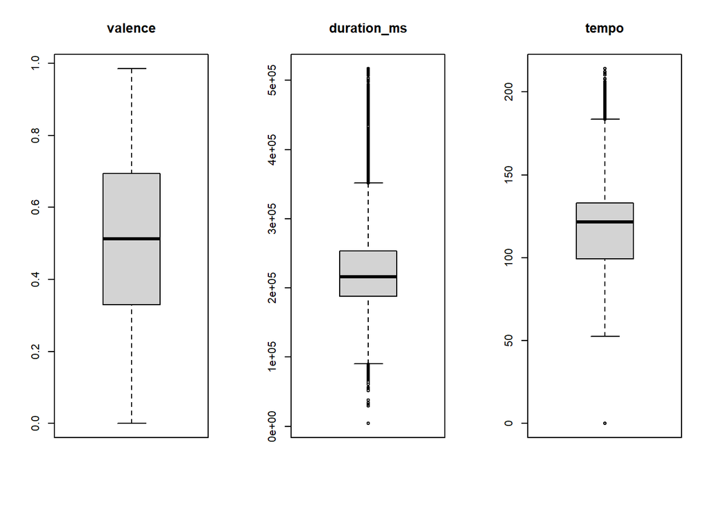

```r
par(mfrow = c(1, 3))

boxplot(spotify_sampled_data[, 21], main = names(spotify_sampled_data)[21])
boxplot(spotify_sampled_data[, 23], main = names(spotify_sampled_data)[23])
boxplot(spotify_sampled_data[, 22], main = names(spotify_sampled_data)[22])
```

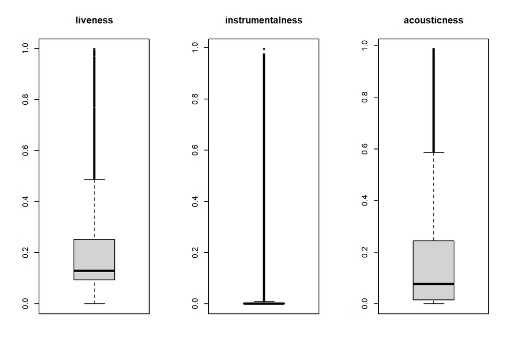

```r
boxplot(spotify_sampled_data[, 20], main = names(spotify_sampled_data)[20])
boxplot(spotify_sampled_data[, 19], main = names(spotify_sampled_data)[19])
boxplot(spotify_sampled_data[, 18], main = names(spotify_sampled_data)[18])
```

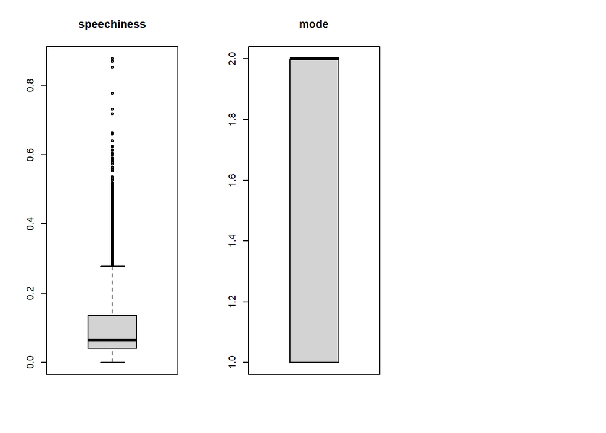

```r
boxplot(spotify_sampled_data[, 17], main = names(spotify_sampled_data)[17])
boxplot(spotify_sampled_data[, 16], main = names(spotify_sampled_data)[16])
```

Creating a map to identify the missing data in each dataset loading necessary datasets

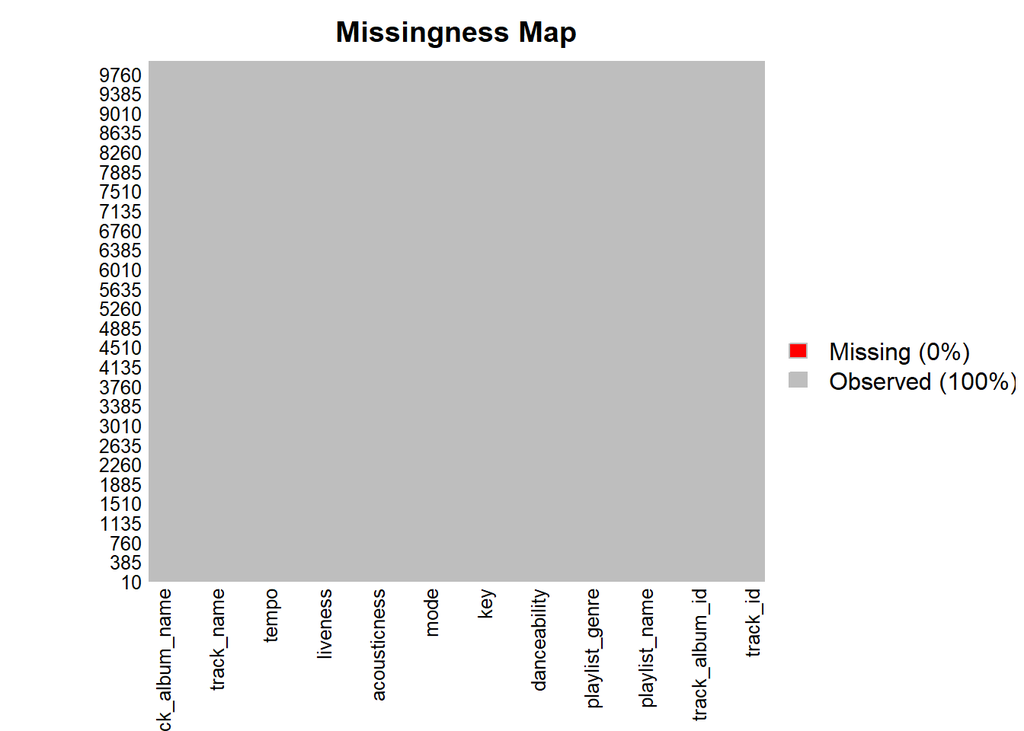

```r
if (!is.element("Amelia", installed.packages()[, 1])) {
  install.packages("Amelia", dependencies = TRUE)
}
require("Amelia")
missmap(spotify_sampled_data, col = c("red", "grey"), legend = TRUE)
```

```r
if (!is.element("corrplot", installed.packages()[, 1])) {
  install.packages("corrplot", dependencies = TRUE)
}
require("corrplot")
```

We now create a correlation plot

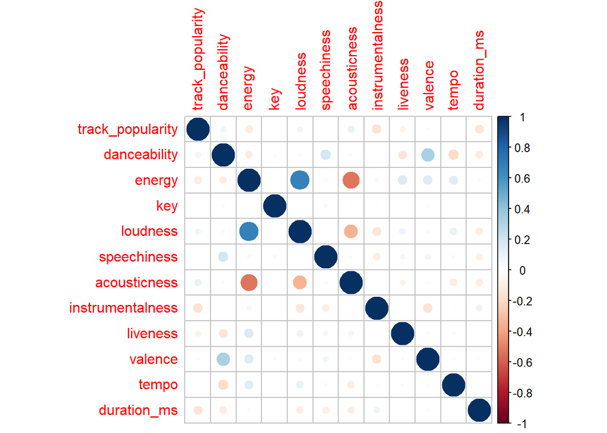

```r
corrplot(cor(spotify_sampled_data[c(4,12,13,14,15,17,18,19,20,21,22,23)]), method = "circle")
```

We will now perform data Imputation. We will try and check for missing values and try to remove them for data consistency.

First we will install the necessary packages to perform imputation

```r
if(!is.element("NHANES", installed.packages()[, 1])){
  install.packages("NHANES", dependencies = TRUE,
                   repos = "https://cloud.r-project.org")
}

require("NHANES")
if(!is.element("dplyr", installed.packages()[, 1])){
  install.packages("dplyr", dependencies=TRUE,
                   repos = "https://cloud.r-project.org")
}

require("dplyr")


if(!is.element("naniar", installed.packages()[, 1])){
  install.packages("naniar", dependencies = TRUE,
                   repos = "https://cloud.r-project.org")
}

require("naniar")
if(!is.element("mice", installed.packages()[, 1])){
  install.packages("mince", dependencies = TRUE,
                   repos = "https://cloud.r-project.org")
}

require("mice")
if(!is.element("Amelia", installed.packages()[, 1])){
  install.packages("Amelia", dependencies = TRUE,
                   repos="https://cloud.r-project.org")
}

require("Amelia")
```

We now confirm if there are any missing value

```r
any_na(spotify_sampled_data)
```

```
## [1] TRUE
```

We check how many are missing

```r
n_miss(spotify_sampled_data)
```

```
## [1] 3
```

For clarity, we check what percentage of missing data is in the entire dataset

```r
prop_miss(spotify_sampled_data)
```

```
## [1] 1.304348e-05
```

How many missing values does each variable have

```r
spotify_sampled_data %>% is.na() %>% colSums()
```

```
##                 track_id               track_name             track_artist
##                        0                        1                        1
##         track_popularity           track_album_id         track_album_name
##                        0                        0                        1
## track_album_release_date            playlist_name              playlist_id
##                        0                        0                        0
##           playlist_genre        playlist_subgenre             danceability
##                        0                        0                        0
##                   energy                      key                 loudness
##                        0                        0                        0
##                     mode              speechiness             acousticness
##                        0                        0                        0
##         instrumentalness                 liveness                  valence
##                        0                        0                        0
##                    tempo              duration_ms
##                        0                        0
```

Checking the number and percentage of missing values grouped by each observation

```r
miss_var_summary(spotify_sampled_data)
```

```
## # A tibble: 23 × 3
##    variable                 n_miss pct_miss
##    <chr>                     <int>    <dbl>
##  1 track_name                    1     0.01
##  2 track_artist                  1     0.01
##  3 track_album_name              1     0.01
##  4 track_id                      0     0
##  5 track_popularity              0     0
##  6 track_album_id                0     0
##  7 track_album_release_date      0     0
##  8 playlist_name                 0     0
##  9 playlist_id                   0     0
## 10 playlist_genre                0     0
## # ℹ 13 more rows
```

```r
miss_case_summary(spotify_sampled_data)
```

```
## # A tibble: 10,000 × 3
##     case n_miss pct_miss
##    <int>  <int>    <dbl>
##  1   279      3     13.0
##  2     1      0      0
##  3     2      0      0
##  4     3      0      0
##  5     4      0      0
##  6     5      0      0
##  7     6      0      0
##  8     7      0      0
##  9     8      0      0
## 10     9      0      0
## # ℹ 9,990 more rows
```

Checking which variable contain the most missing values

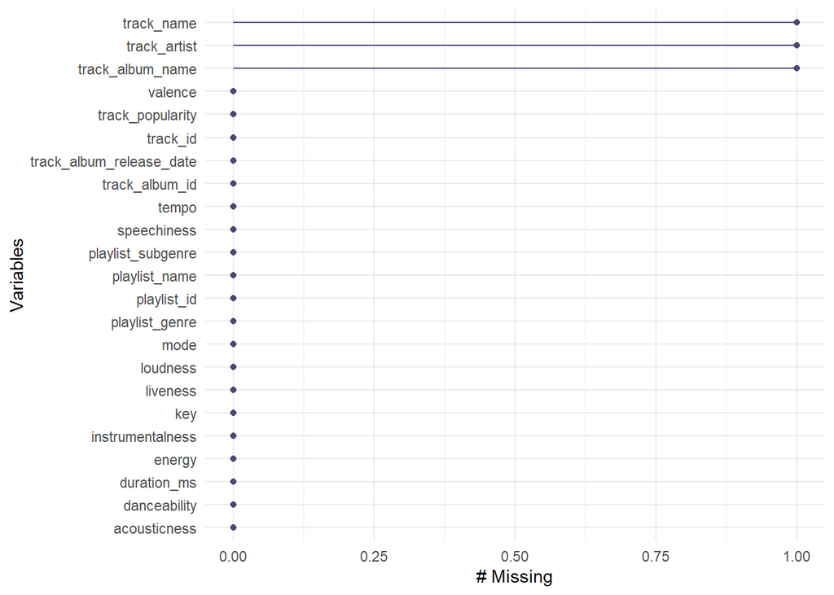

```r
gg_miss_var(spotify_sampled_data)
```

which combinations fo variables are missing together

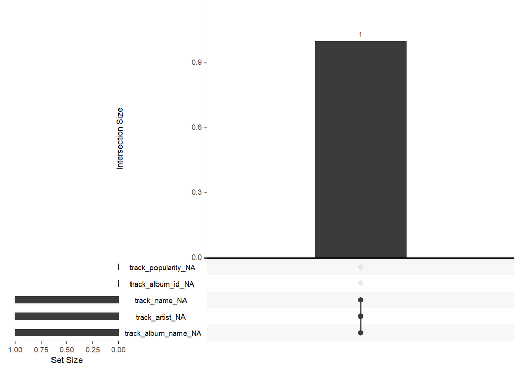

```r
gg_miss_upset(spotify_sampled_data)
```

```r
is.factor(spotify_sampled_data$track_name)
```

```
## [1] FALSE
```

Now we will perfrom data Transformation necessary for improving the accuracy of the final model.

```r
if(!is.element("caret", installed.packages()[, 1])){
  install.packages("caret", dependencies = TRUE,
                   repos = "https://cloud.r-project.org")

}
require("caret")
model_of_the_transform <- preProcess(spotify_sampled_data, method=c("scale"))
print(model_of_the_transform)
```

```
## Created from 9999 samples and 23 variables
##
## Pre-processing:
##   - ignored (11)
##   - scaled (12)
```

```r
spotify_songs_scale_transform <- predict(model_of_the_transform, spotify_sampled_data)

summary(spotify_songs_scale_transform)
```

```
##    track_id          track_name        track_artist       track_popularity
##  Length:10000       Length:10000       Length:10000       Min.   :0.0000
##  Class :character   Class :character   Class :character   1st Qu.:0.9591
##  Mode  :character   Mode  :character   Mode  :character   Median :1.7984
##                                                           Mean   :1.7017
##                                                           3rd Qu.:2.4777
##                                                           Max.   :3.9564
##  track_album_id     track_album_name   track_album_release_date
##  Length:10000       Length:10000       Length:10000
##  Class :character   Class :character   Class :character
##  Mode  :character   Mode  :character   Mode  :character
##
##
##
##  playlist_name      playlist_id        playlist_genre playlist_subgenre
##  Length:10000       Length:10000       edm  :1822     Length:10000
##  Class :character   Class :character   pop  :1661     Class :character
##  Mode  :character   Mode  :character   latin:1550     Mode  :character
##                                        r&b  :1638
##                                        rap  :1761
##                                        rock :1568
##   danceability       energy             key            loudness        mode
##  Min.   :0.000   Min.   :0.04522   Min.   :0.0000   Min.   :-11.4703   0:4320
##  1st Qu.:3.854   1st Qu.:3.23904   1st Qu.:0.5557   1st Qu.: -2.7396   1:5680
##  Median :4.612   Median :4.00574   Median :1.6672   Median : -2.0635
##  Mean   :4.505   Mean   :3.88294   Mean   :1.4963   Mean   : -2.2592
##  3rd Qu.:5.232   3rd Qu.:4.66133   3rd Qu.:2.2229   3rd Qu.: -1.5665
##  Max.   :6.776   Max.   :5.55582   Max.   :3.0565   Max.   :  0.3797
##   speechiness      acousticness     instrumentalness      liveness
##  Min.   :0.0000   Min.   :0.00000   Min.   :0.000000   Min.   :0.0000
##  1st Qu.:0.4067   1st Qu.:0.06998   1st Qu.:0.000000   1st Qu.:0.5873
##  Median :0.6298   Median :0.35524   Median :0.000069   Median :0.8130
##  Mean   :1.0684   Mean   :0.78833   Mean   :0.368298   Mean   :1.2203
##  3rd Qu.:1.3425   3rd Qu.:1.13085   3rd Qu.:0.017435   3rd Qu.:1.5834
##  Max.   :8.6572   Max.   :4.56975   Max.   :4.581780   Max.   :6.2768
##     valence          tempo        duration_ms
##  Min.   :0.000   Min.   :0.000   Min.   :0.06727
##  1st Qu.:1.427   1st Qu.:3.688   1st Qu.:3.15836
##  Median :2.218   Median :4.514   Median :3.63470
##  Mean   :2.205   Mean   :4.481   Mean   :3.79283
##  3rd Qu.:3.000   3rd Qu.:4.943   3rd Qu.:4.26063
##  Max.   :4.258   Max.   :7.953   Max.   :8.69326
```

# Center Data Transform

Before

```r
summary(spotify_sampled_data)
```

```
##    track_id          track_name        track_artist       track_popularity
##  Length:10000       Length:10000       Length:10000       Min.   : 0.00
##  Class :character   Class :character   Class :character   1st Qu.:24.00
##  Mode  :character   Mode  :character   Mode  :character   Median :45.00
##                                                           Mean   :42.58
##                                                           3rd Qu.:62.00
##                                                           Max.   :99.00
##  track_album_id     track_album_name   track_album_release_date
##  Length:10000       Length:10000       Length:10000
##  Class :character   Class :character   Class :character
##  Mode  :character   Mode  :character   Mode  :character
##
##
##
##  playlist_name      playlist_id        playlist_genre playlist_subgenre
##  Length:10000       Length:10000       edm  :1822     Length:10000
##  Class :character   Class :character   pop  :1661     Class :character
##  Mode  :character   Mode  :character   latin:1550     Mode  :character
##                                        r&b  :1638
##                                        rap  :1761
##                                        rock :1568
##   danceability        energy             key            loudness       mode
##  Min.   :0.0000   Min.   :0.00814   Min.   : 0.000   Min.   :-34.283   0:4320
##  1st Qu.:0.5590   1st Qu.:0.58300   1st Qu.: 2.000   1st Qu.: -8.188   1:5680
##  Median :0.6690   Median :0.72100   Median : 6.000   Median : -6.168
##  Mean   :0.6535   Mean   :0.69890   Mean   : 5.385   Mean   : -6.752
##  3rd Qu.:0.7590   3rd Qu.:0.83900   3rd Qu.: 8.000   3rd Qu.: -4.682
##  Max.   :0.9830   Max.   :1.00000   Max.   :11.000   Max.   :  1.135
##   speechiness      acousticness     instrumentalness       liveness
##  Min.   :0.0000   Min.   :0.00000   Min.   :0.0000000   Min.   :0.0000
##  1st Qu.:0.0412   1st Qu.:0.01510   1st Qu.:0.0000000   1st Qu.:0.0932
##  Median :0.0638   Median :0.07665   Median :0.0000149   Median :0.1290
##  Mean   :0.1082   Mean   :0.17009   Mean   :0.0799010   Mean   :0.1936
##  3rd Qu.:0.1360   3rd Qu.:0.24400   3rd Qu.:0.0037825   3rd Qu.:0.2512
##  Max.   :0.8770   Max.   :0.98600   Max.   :0.9940000   Max.   :0.9960
##     valence          tempo         duration_ms
##  Min.   :0.000   Min.   :  0.00   Min.   :  4000
##  1st Qu.:0.330   1st Qu.: 99.25   1st Qu.:187793
##  Median :0.513   Median :121.48   Median :216116
##  Mean   :0.510   Mean   :120.60   Mean   :225518
##  3rd Qu.:0.694   3rd Qu.:133.03   3rd Qu.:253333
##  Max.   :0.985   Max.   :214.05   Max.   :516893
```

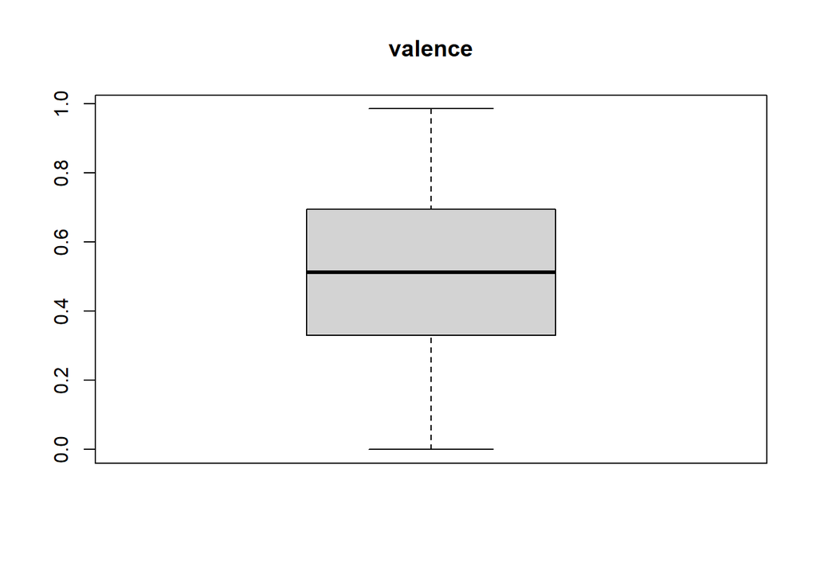

```r
boxplot(spotify_sampled_data[, 21], main = names(spotify_sampled_data)[21])
```

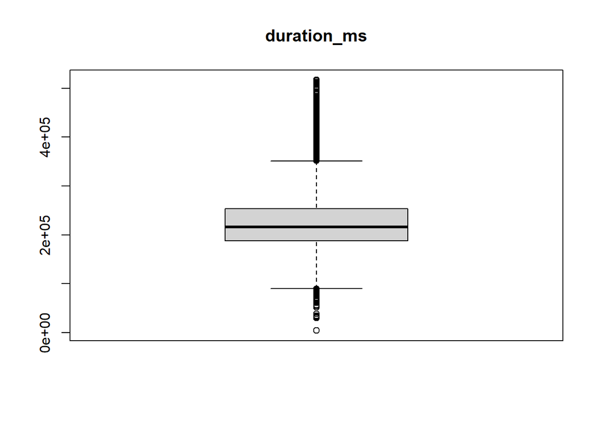

```r
boxplot(spotify_sampled_data[, 23], main = names(spotify_sampled_data)[23])
```

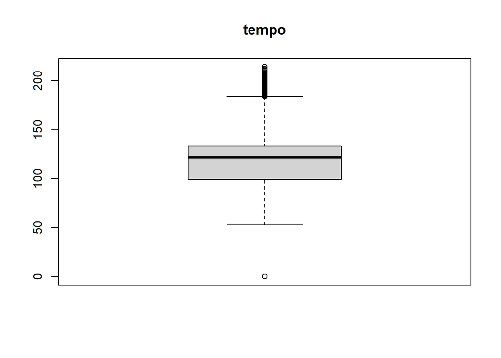

```r
boxplot(spotify_sampled_data[, 22], main = names(spotify_sampled_data)[22])
```

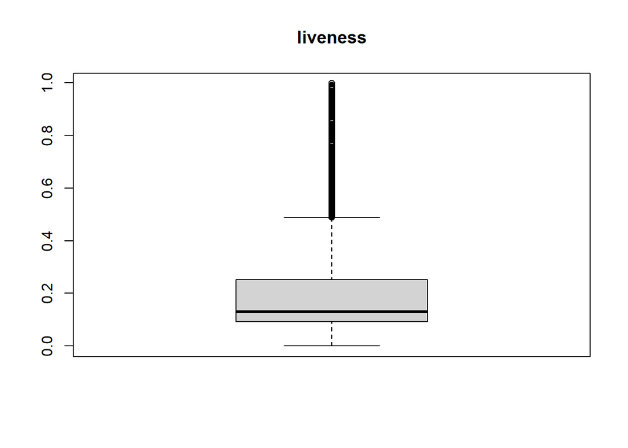

```r
boxplot(spotify_sampled_data[, 20], main = names(spotify_sampled_data)[20])
```

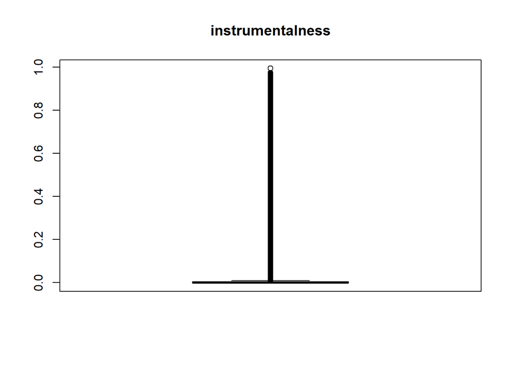

```r
boxplot(spotify_sampled_data[, 19], main = names(spotify_sampled_data)[19])
```

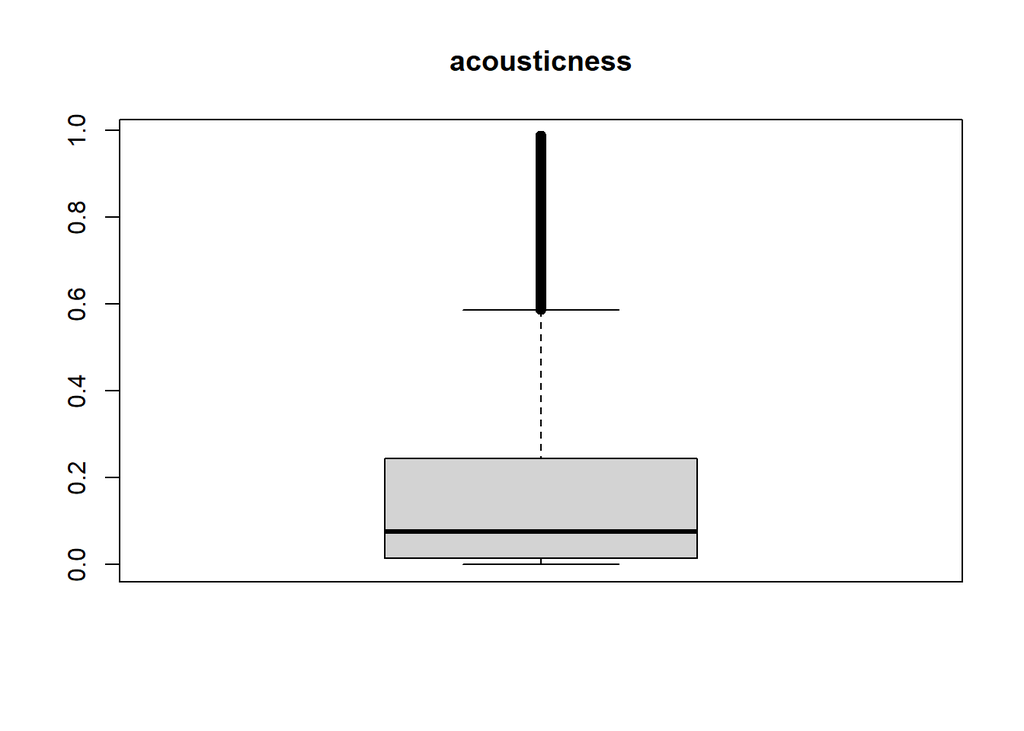

```r
boxplot(spotify_sampled_data[, 18], main = names(spotify_sampled_data)[18])
```

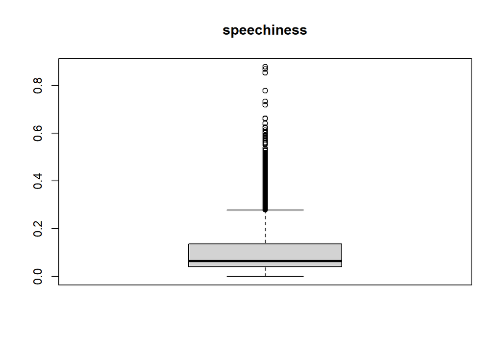

```r
boxplot(spotify_sampled_data[, 17], main = names(spotify_sampled_data)[17])
```

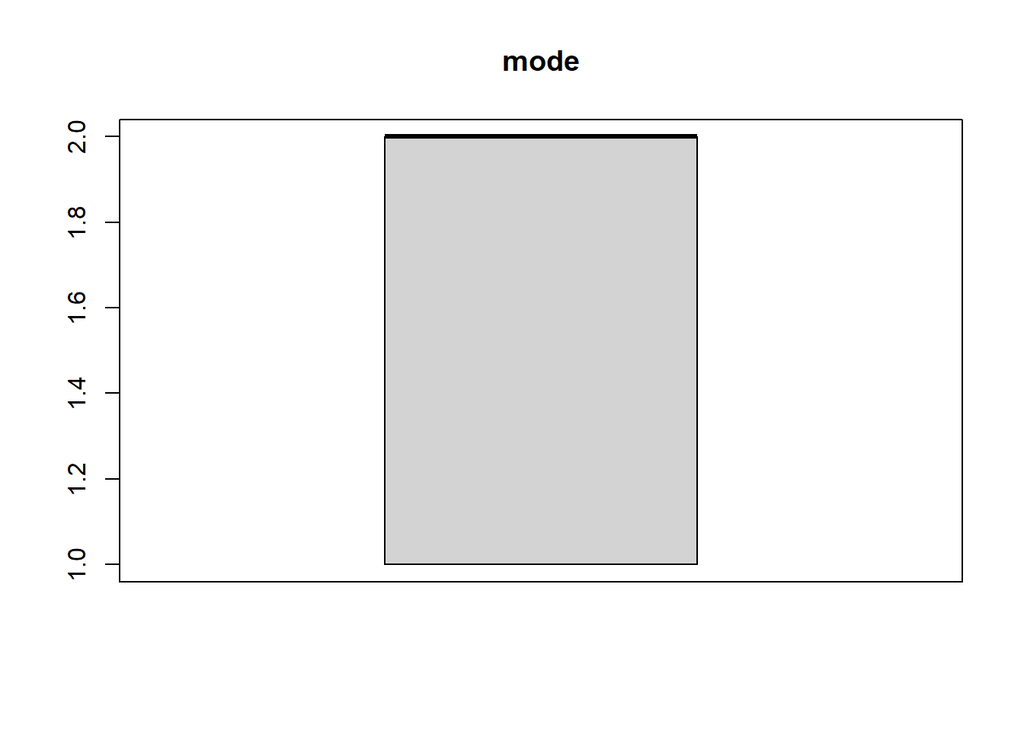

```r
boxplot(spotify_sampled_data[, 16], main = names(spotify_sampled_data)[16])
```

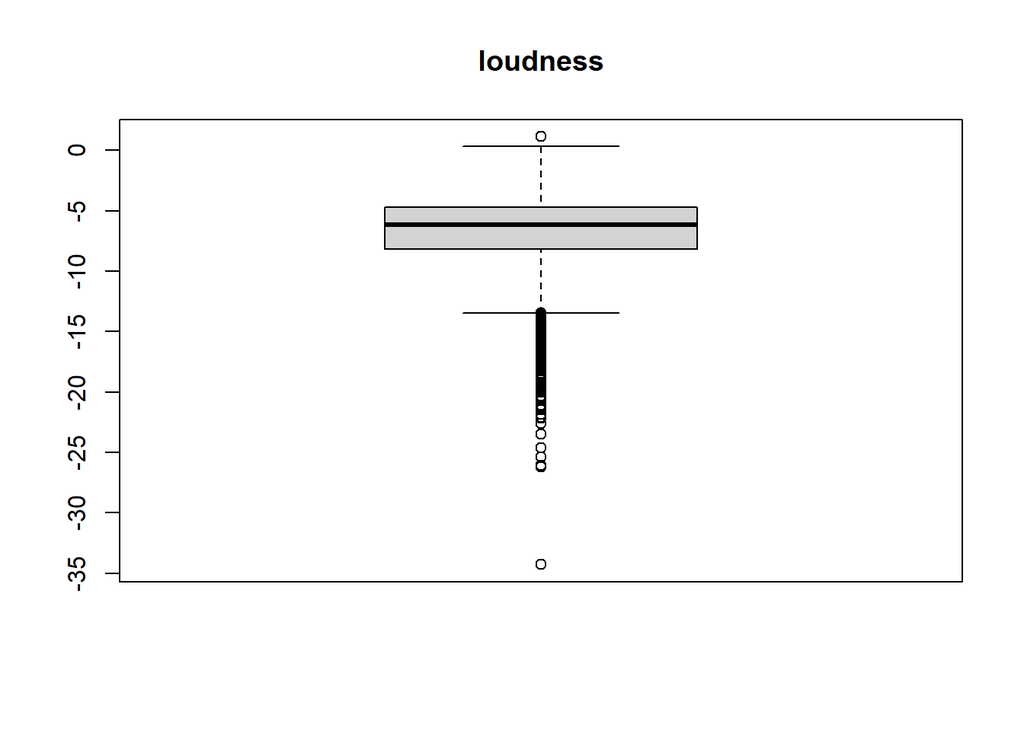

```r
boxplot(spotify_sampled_data[, 15], main = names(spotify_sampled_data)[15])
```

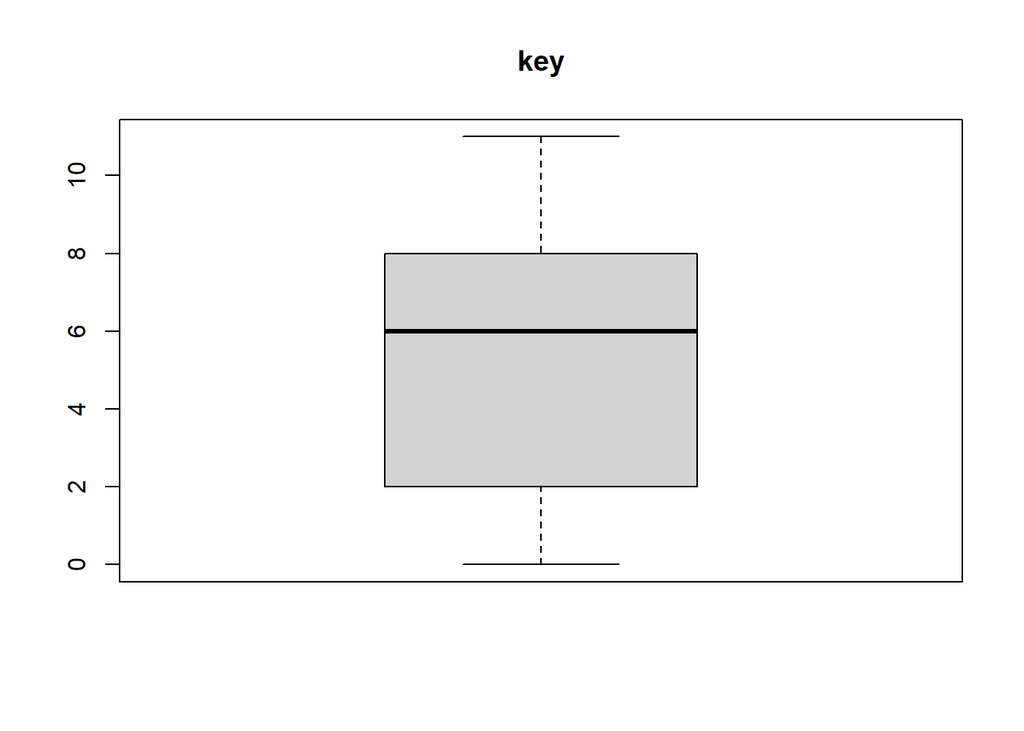

```r
boxplot(spotify_sampled_data[, 14], main = names(spotify_sampled_data)[14])
```

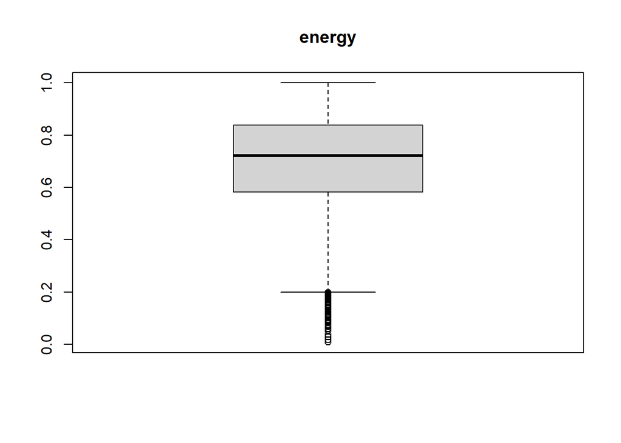

```r
boxplot(spotify_sampled_data[, 13], main = names(spotify_sampled_data)[13])
```

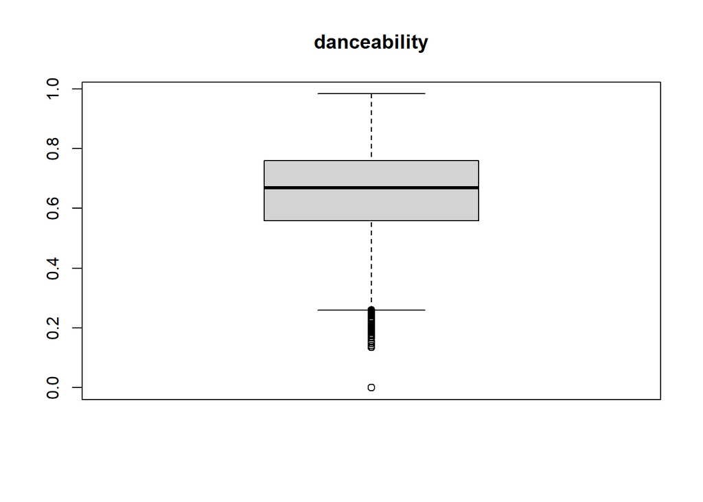

```r
boxplot(spotify_sampled_data[, 12], main = names(spotify_sampled_data)[12])
```

```r
model_of_the_transform <- preProcess(spotify_sampled_data, method = c("center"))
print(model_of_the_transform)
```

```
## Created from 9999 samples and 23 variables
##
## Pre-processing:
##   - centered (12)
##   - ignored (11)
```

```r
spotify_data_center_transform<- predict(model_of_the_transform, # nolint
                                           spotify_sampled_data)
```

After

```r
summary(spotify_data_center_transform)
```

```
##    track_id          track_name        track_artist       track_popularity
##  Length:10000       Length:10000       Length:10000       Min.   :-42.58
##  Class :character   Class :character   Class :character   1st Qu.:-18.58
##  Mode  :character   Mode  :character   Mode  :character   Median :  2.42
##                                                           Mean   :  0.00
##                                                           3rd Qu.: 19.42
##                                                           Max.   : 56.42
##  track_album_id     track_album_name   track_album_release_date
##  Length:10000       Length:10000       Length:10000
##  Class :character   Class :character   Class :character
##  Mode  :character   Mode  :character   Mode  :character
##
##
##
##  playlist_name      playlist_id        playlist_genre playlist_subgenre
##  Length:10000       Length:10000       edm  :1822     Length:10000
##  Class :character   Class :character   pop  :1661     Class :character
##  Mode  :character   Mode  :character   latin:1550     Mode  :character
##                                        r&b  :1638
##                                        rap  :1761
##                                        rock :1568
##   danceability          energy             key            loudness
##  Min.   :-0.65348   Min.   :-0.6908   Min.   :-5.385   Min.   :-27.531
##  1st Qu.:-0.09448   1st Qu.:-0.1159   1st Qu.:-3.385   1st Qu.: -1.436
##  Median : 0.01552   Median : 0.0221   Median : 0.615   Median :  0.585
##  Mean   : 0.00000   Mean   : 0.0000   Mean   : 0.000   Mean   :  0.000
##  3rd Qu.: 0.10552   3rd Qu.: 0.1401   3rd Qu.: 2.615   3rd Qu.:  2.070
##  Max.   : 0.32952   Max.   : 0.3011   Max.   : 5.615   Max.   :  7.887
##  mode      speechiness        acousticness      instrumentalness
##  0:4320   Min.   :-0.10823   Min.   :-0.17009   Min.   :-0.07990
##  1:5680   1st Qu.:-0.06703   1st Qu.:-0.15499   1st Qu.:-0.07990
##           Median :-0.04443   Median :-0.09344   Median :-0.07989
##           Mean   : 0.00000   Mean   : 0.00000   Mean   : 0.00000
##           3rd Qu.: 0.02777   3rd Qu.: 0.07391   3rd Qu.:-0.07612
##           Max.   : 0.76877   Max.   : 0.81591   Max.   : 0.91410
##     liveness           valence              tempo            duration_ms
##  Min.   :-0.19364   Min.   :-0.509993   Min.   :-120.6023   Min.   :-221518
##  1st Qu.:-0.10044   1st Qu.:-0.179993   1st Qu.: -21.3505   1st Qu.: -37725
##  Median :-0.06464   Median : 0.003007   Median :   0.8762   Median :  -9402
##  Mean   : 0.00000   Mean   : 0.000000   Mean   :   0.0000   Mean   :      0
##  3rd Qu.: 0.05761   3rd Qu.: 0.184007   3rd Qu.:  12.4317   3rd Qu.:  27815
##  Max.   : 0.80236   Max.   : 0.475007   Max.   :  93.4447   Max.   : 291375
```

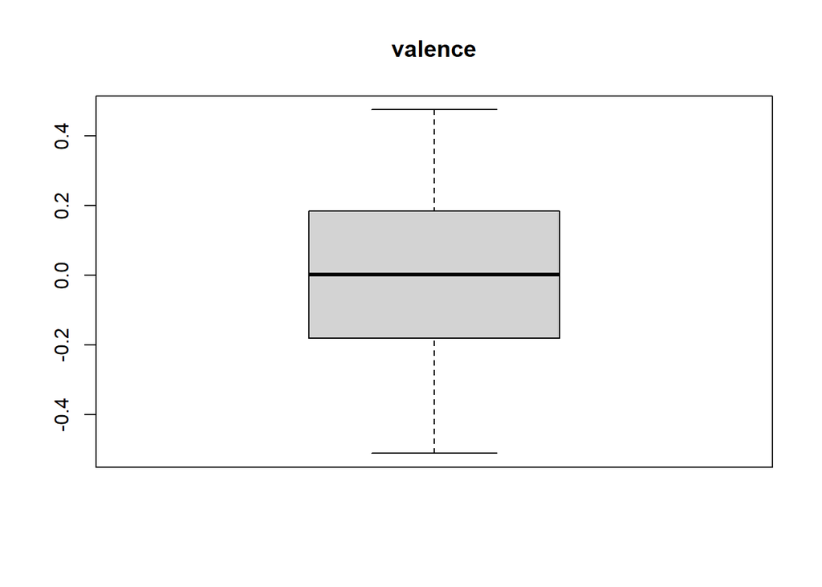

```r
boxplot(spotify_data_center_transform[, 21],
        main = names(spotify_data_center_transform)[21])
```

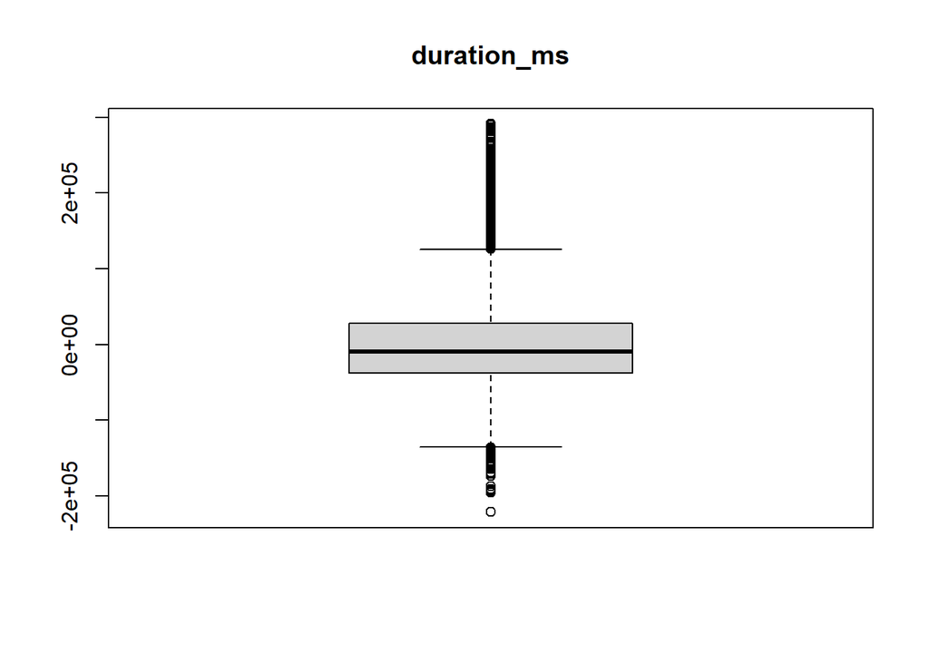

```r
boxplot(spotify_data_center_transform[, 23],
        main = names(spotify_data_center_transform)[23])
```

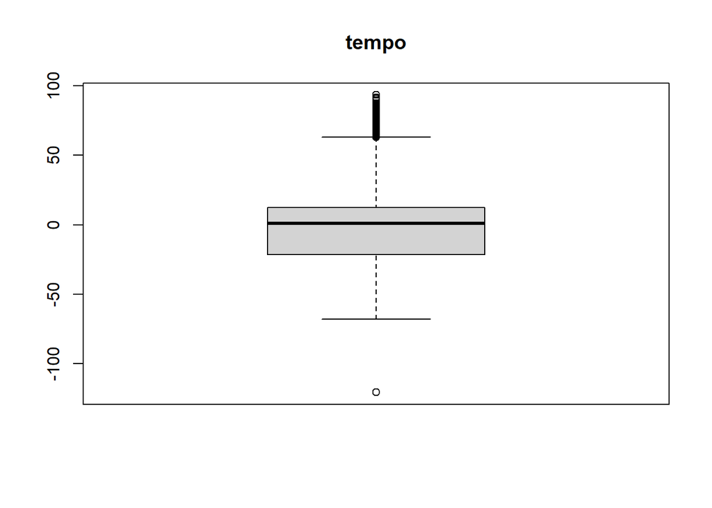

```r
boxplot(spotify_data_center_transform[, 22],
        main = names(spotify_data_center_transform)[22])
```

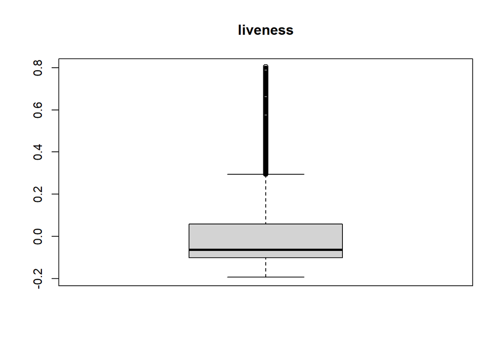

```r
boxplot(spotify_data_center_transform[, 20],
        main = names(spotify_data_center_transform)[20])
```

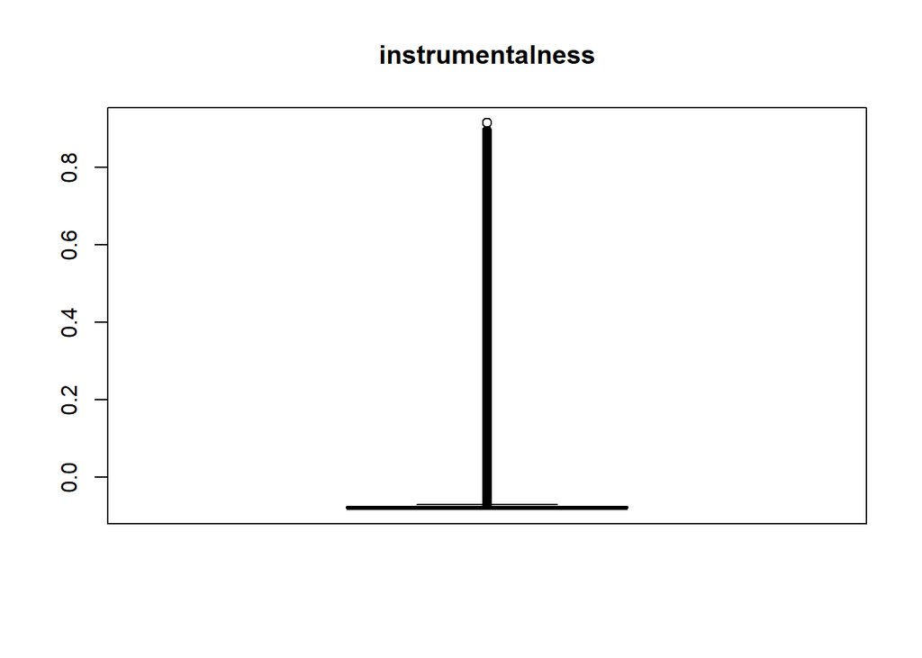

```r
boxplot(spotify_data_center_transform[, 19],
        main = names(spotify_data_center_transform)[19])
```

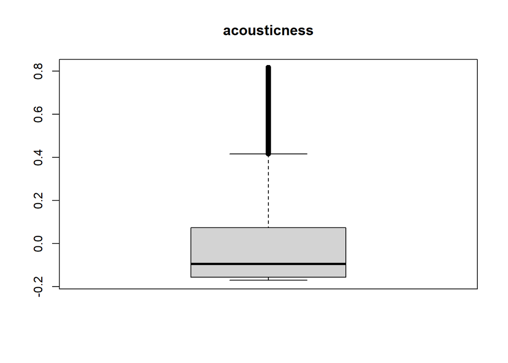

```r
boxplot(spotify_data_center_transform[, 18],
        main = names(spotify_data_center_transform)[18])
```

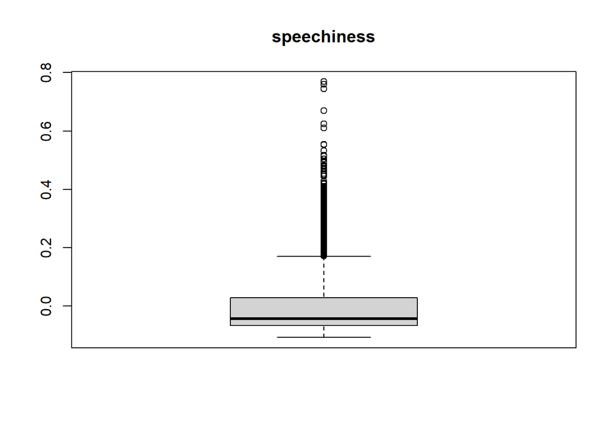

```r
boxplot(spotify_data_center_transform[, 17],
        main = names(spotify_data_center_transform)[17])
```

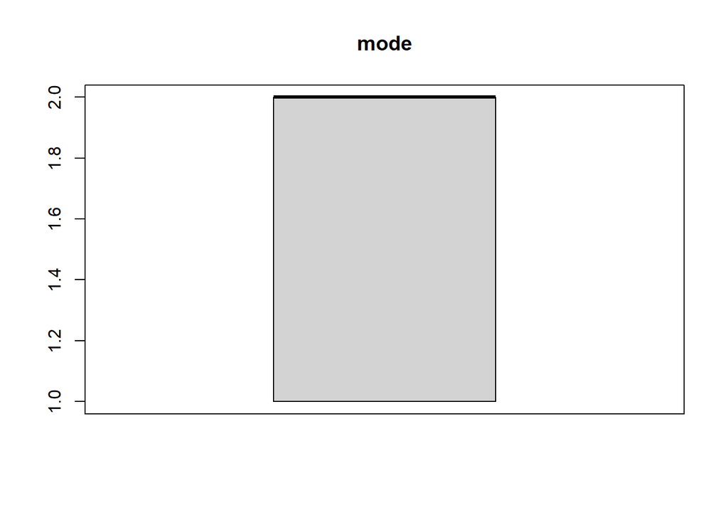

```r
boxplot(spotify_data_center_transform[, 16],
        main = names(spotify_data_center_transform)[16])
```

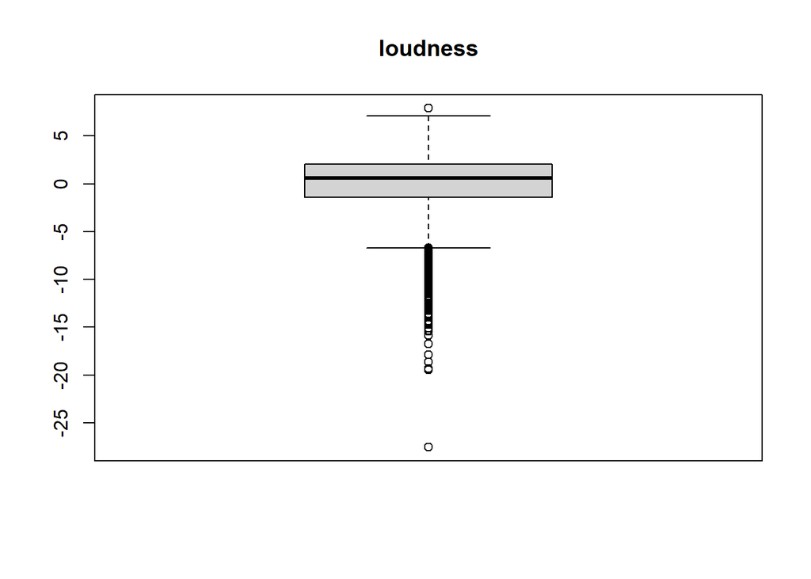

```r
boxplot(spotify_data_center_transform[, 15],
        main = names(spotify_data_center_transform)[15])
```

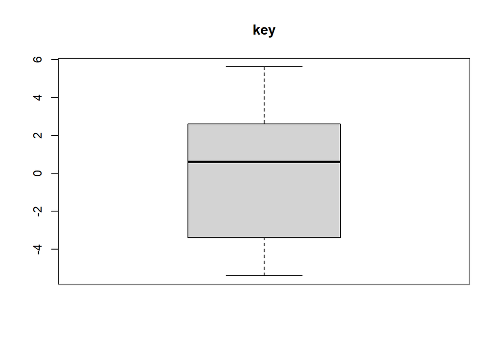

```r
boxplot(spotify_data_center_transform[, 14],
        main = names(spotify_data_center_transform)[14])
```

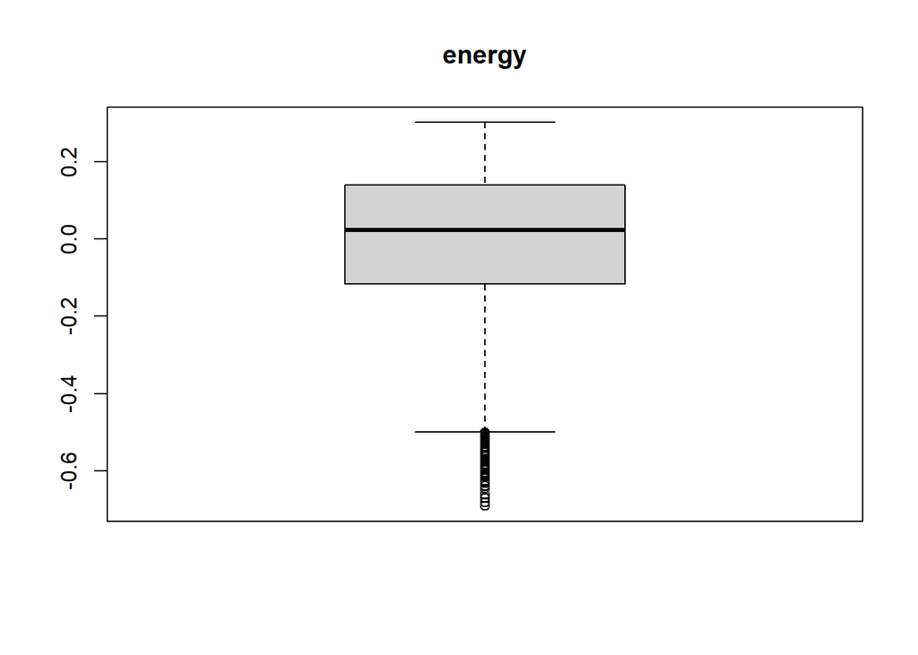

```r
boxplot(spotify_data_center_transform[, 13],
        main = names(spotify_data_center_transform)[13])
```

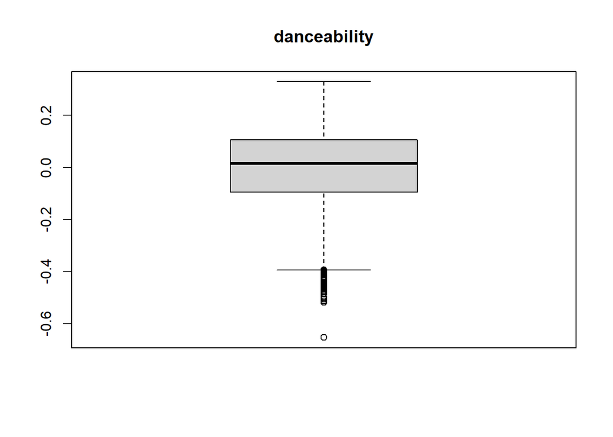

```r
boxplot(spotify_data_center_transform[, 12],
        main = names(spotify_data_center_transform)[12])
```

# Standadize data transformation

Before

```r
summary(spotify_sampled_data)
```

```
##    track_id          track_name        track_artist       track_popularity
##  Length:10000       Length:10000       Length:10000       Min.   : 0.00
##  Class :character   Class :character   Class :character   1st Qu.:24.00
##  Mode  :character   Mode  :character   Mode  :character   Median :45.00
##                                                           Mean   :42.58
##                                                           3rd Qu.:62.00
##                                                           Max.   :99.00
##  track_album_id     track_album_name   track_album_release_date
##  Length:10000       Length:10000       Length:10000
##  Class :character   Class :character   Class :character
##  Mode  :character   Mode  :character   Mode  :character
##
##
##
##  playlist_name      playlist_id        playlist_genre playlist_subgenre
##  Length:10000       Length:10000       edm  :1822     Length:10000
##  Class :character   Class :character   pop  :1661     Class :character
##  Mode  :character   Mode  :character   latin:1550     Mode  :character
##                                        r&b  :1638
##                                        rap  :1761
##                                        rock :1568
##   danceability        energy             key            loudness       mode
##  Min.   :0.0000   Min.   :0.00814   Min.   : 0.000   Min.   :-34.283   0:4320
##  1st Qu.:0.5590   1st Qu.:0.58300   1st Qu.: 2.000   1st Qu.: -8.188   1:5680
##  Median :0.6690   Median :0.72100   Median : 6.000   Median : -6.168
##  Mean   :0.6535   Mean   :0.69890   Mean   : 5.385   Mean   : -6.752
##  3rd Qu.:0.7590   3rd Qu.:0.83900   3rd Qu.: 8.000   3rd Qu.: -4.682
##  Max.   :0.9830   Max.   :1.00000   Max.   :11.000   Max.   :  1.135
##   speechiness      acousticness     instrumentalness       liveness
##  Min.   :0.0000   Min.   :0.00000   Min.   :0.0000000   Min.   :0.0000
##  1st Qu.:0.0412   1st Qu.:0.01510   1st Qu.:0.0000000   1st Qu.:0.0932
##  Median :0.0638   Median :0.07665   Median :0.0000149   Median :0.1290
##  Mean   :0.1082   Mean   :0.17009   Mean   :0.0799010   Mean   :0.1936
##  3rd Qu.:0.1360   3rd Qu.:0.24400   3rd Qu.:0.0037825   3rd Qu.:0.2512
##  Max.   :0.8770   Max.   :0.98600   Max.   :0.9940000   Max.   :0.9960
##     valence          tempo         duration_ms
##  Min.   :0.000   Min.   :  0.00   Min.   :  4000
##  1st Qu.:0.330   1st Qu.: 99.25   1st Qu.:187793
##  Median :0.513   Median :121.48   Median :216116
##  Mean   :0.510   Mean   :120.60   Mean   :225518
##  3rd Qu.:0.694   3rd Qu.:133.03   3rd Qu.:253333
##  Max.   :0.985   Max.   :214.05   Max.   :516893
```

```r
sapply(spotify_sampled_data[, c(4,12,13,14,15,17,18,19,20,21,22,23)], sd)
```

```
## track_popularity     danceability           energy              key
##     2.502277e+01     1.450626e-01     1.799915e-01     3.598871e+00
##         loudness      speechiness     acousticness instrumentalness
##     2.988857e+00     1.013024e-01     2.157667e-01     2.169462e-01
##         liveness          valence            tempo      duration_ms
##     1.586805e-01     2.313135e-01     2.691433e+01     5.945902e+04
```

```r
model_of_the_transform<- preProcess(spotify_sampled_data,
                                    method = c("scale", "center"))

print(model_of_the_transform)
```

```
## Created from 9999 samples and 23 variables
##
## Pre-processing:
##   - centered (12)
##   - ignored (11)
##   - scaled (12)
```

```r
spotify_data_standardize_transform<-predict(model_of_the_transform,
                                           spotify_sampled_data)
```

After

```r
summary(spotify_data_standardize_transform)
```

```
##    track_id          track_name        track_artist       track_popularity
##  Length:10000       Length:10000       Length:10000       Min.   :-1.7017
##  Class :character   Class :character   Class :character   1st Qu.:-0.7425
##  Mode  :character   Mode  :character   Mode  :character   Median : 0.0967
##                                                           Mean   : 0.0000
##                                                           3rd Qu.: 0.7761
##                                                           Max.   : 2.2547
##  track_album_id     track_album_name   track_album_release_date
##  Length:10000       Length:10000       Length:10000
##  Class :character   Class :character   Class :character
##  Mode  :character   Mode  :character   Mode  :character
##
##
##
##  playlist_name      playlist_id        playlist_genre playlist_subgenre
##  Length:10000       Length:10000       edm  :1822     Length:10000
##  Class :character   Class :character   pop  :1661     Class :character
##  Mode  :character   Mode  :character   latin:1550     Mode  :character
##                                        r&b  :1638
##                                        rap  :1761
##                                        rock :1568
##   danceability         energy             key             loudness
##  Min.   :-4.5048   Min.   :-3.8377   Min.   :-1.4963   Min.   :-9.2111
##  1st Qu.:-0.6513   1st Qu.:-0.6439   1st Qu.:-0.9406   1st Qu.:-0.4804
##  Median : 0.1070   Median : 0.1228   Median : 0.1709   Median : 0.1957
##  Mean   : 0.0000   Mean   : 0.0000   Mean   : 0.0000   Mean   : 0.0000
##  3rd Qu.: 0.7274   3rd Qu.: 0.7784   3rd Qu.: 0.7266   3rd Qu.: 0.6927
##  Max.   : 2.2716   Max.   : 1.6729   Max.   : 1.5602   Max.   : 2.6390
##  mode      speechiness       acousticness     instrumentalness
##  0:4320   Min.   :-1.0684   Min.   :-0.7883   Min.   :-0.3683
##  1:5680   1st Qu.:-0.6617   1st Qu.:-0.7183   1st Qu.:-0.3683
##           Median :-0.4386   Median :-0.4331   Median :-0.3682
##           Mean   : 0.0000   Mean   : 0.0000   Mean   : 0.0000
##           3rd Qu.: 0.2741   3rd Qu.: 0.3425   3rd Qu.:-0.3509
##           Max.   : 7.5888   Max.   : 3.7814   Max.   : 4.2135
##     liveness          valence            tempo           duration_ms
##  Min.   :-1.2203   Min.   :-2.2048   Min.   :-4.48097   Min.   :-3.7256
##  1st Qu.:-0.6330   1st Qu.:-0.7781   1st Qu.:-0.79328   1st Qu.:-0.6345
##  Median :-0.4074   Median : 0.0130   Median : 0.03256   Median :-0.1581
##  Mean   : 0.0000   Mean   : 0.0000   Mean   : 0.00000   Mean   : 0.0000
##  3rd Qu.: 0.3631   3rd Qu.: 0.7955   3rd Qu.: 0.46190   3rd Qu.: 0.4678
##  Max.   : 5.0564   Max.   : 2.0535   Max.   : 3.47193   Max.   : 4.9004
```

```r
sapply(spotify_data_standardize_transform[, c(4,12,13,14,15,17,18,19,20,21,22,23)], sd)
```

```
## track_popularity     danceability           energy              key
##                1                1                1                1
##         loudness      speechiness     acousticness instrumentalness
##                1                1                1                1
##         liveness          valence            tempo      duration_ms
##                1                1                1                1
```

# Normalize data Transform

```r
summary(spotify_sampled_data)
```

```
##    track_id          track_name        track_artist       track_popularity
##  Length:10000       Length:10000       Length:10000       Min.   : 0.00
##  Class :character   Class :character   Class :character   1st Qu.:24.00
##  Mode  :character   Mode  :character   Mode  :character   Median :45.00
##                                                           Mean   :42.58
##                                                           3rd Qu.:62.00
##                                                           Max.   :99.00
##  track_album_id     track_album_name   track_album_release_date
##  Length:10000       Length:10000       Length:10000
##  Class :character   Class :character   Class :character
##  Mode  :character   Mode  :character   Mode  :character
##
##
##
##  playlist_name      playlist_id        playlist_genre playlist_subgenre
##  Length:10000       Length:10000       edm  :1822     Length:10000
##  Class :character   Class :character   pop  :1661     Class :character
##  Mode  :character   Mode  :character   latin:1550     Mode  :character
##                                        r&b  :1638
##                                        rap  :1761
##                                        rock :1568
##   danceability        energy             key            loudness       mode
##  Min.   :0.0000   Min.   :0.00814   Min.   : 0.000   Min.   :-34.283   0:4320
##  1st Qu.:0.5590   1st Qu.:0.58300   1st Qu.: 2.000   1st Qu.: -8.188   1:5680
##  Median :0.6690   Median :0.72100   Median : 6.000   Median : -6.168
##  Mean   :0.6535   Mean   :0.69890   Mean   : 5.385   Mean   : -6.752
##  3rd Qu.:0.7590   3rd Qu.:0.83900   3rd Qu.: 8.000   3rd Qu.: -4.682
##  Max.   :0.9830   Max.   :1.00000   Max.   :11.000   Max.   :  1.135
##   speechiness      acousticness     instrumentalness       liveness
##  Min.   :0.0000   Min.   :0.00000   Min.   :0.0000000   Min.   :0.0000
##  1st Qu.:0.0412   1st Qu.:0.01510   1st Qu.:0.0000000   1st Qu.:0.0932
##  Median :0.0638   Median :0.07665   Median :0.0000149   Median :0.1290
##  Mean   :0.1082   Mean   :0.17009   Mean   :0.0799010   Mean   :0.1936
##  3rd Qu.:0.1360   3rd Qu.:0.24400   3rd Qu.:0.0037825   3rd Qu.:0.2512
##  Max.   :0.8770   Max.   :0.98600   Max.   :0.9940000   Max.   :0.9960
##     valence          tempo         duration_ms
##  Min.   :0.000   Min.   :  0.00   Min.   :  4000
##  1st Qu.:0.330   1st Qu.: 99.25   1st Qu.:187793
##  Median :0.513   Median :121.48   Median :216116
##  Mean   :0.510   Mean   :120.60   Mean   :225518
##  3rd Qu.:0.694   3rd Qu.:133.03   3rd Qu.:253333
##  Max.   :0.985   Max.   :214.05   Max.   :516893
```

```r
model_of_the_transform <- preProcess(spotify_sampled_data, method = c("range"))
print(model_of_the_transform)
```

```
## Created from 9999 samples and 23 variables
##
## Pre-processing:
##   - ignored (11)
##   - re-scaling to [0, 1] (12)
```

```r
spotify_data_normalize_transform <- predict(model_of_the_transform,
                                            spotify_sampled_data)

summary(spotify_data_normalize_transform)
```

```
##    track_id          track_name        track_artist       track_popularity
##  Length:10000       Length:10000       Length:10000       Min.   :0.0000
##  Class :character   Class :character   Class :character   1st Qu.:0.2424
##  Mode  :character   Mode  :character   Mode  :character   Median :0.4545
##                                                           Mean   :0.4301
##                                                           3rd Qu.:0.6263
##                                                           Max.   :1.0000
##  track_album_id     track_album_name   track_album_release_date
##  Length:10000       Length:10000       Length:10000
##  Class :character   Class :character   Class :character
##  Mode  :character   Mode  :character   Mode  :character
##
##
##
##  playlist_name      playlist_id        playlist_genre playlist_subgenre
##  Length:10000       Length:10000       edm  :1822     Length:10000
##  Class :character   Class :character   pop  :1661     Class :character
##  Mode  :character   Mode  :character   latin:1550     Mode  :character
##                                        r&b  :1638
##                                        rap  :1761
##                                        rock :1568
##   danceability        energy            key            loudness      mode
##  Min.   :0.0000   Min.   :0.0000   Min.   :0.0000   Min.   :0.0000   0:4320
##  1st Qu.:0.5687   1st Qu.:0.5796   1st Qu.:0.1818   1st Qu.:0.7368   1:5680
##  Median :0.6806   Median :0.7187   Median :0.5455   Median :0.7938
##  Mean   :0.6648   Mean   :0.6964   Mean   :0.4895   Mean   :0.7773
##  3rd Qu.:0.7721   3rd Qu.:0.8377   3rd Qu.:0.7273   3rd Qu.:0.8358
##  Max.   :1.0000   Max.   :1.0000   Max.   :1.0000   Max.   :1.0000
##   speechiness       acousticness     instrumentalness      liveness
##  Min.   :0.00000   Min.   :0.00000   Min.   :0.000000   Min.   :0.00000
##  1st Qu.:0.04698   1st Qu.:0.01531   1st Qu.:0.000000   1st Qu.:0.09357
##  Median :0.07275   Median :0.07774   Median :0.000015   Median :0.12952
##  Mean   :0.12341   Mean   :0.17251   Mean   :0.080383   Mean   :0.19442
##  3rd Qu.:0.15507   3rd Qu.:0.24746   3rd Qu.:0.003805   3rd Qu.:0.25226
##  Max.   :1.00000   Max.   :1.00000   Max.   :1.000000   Max.   :1.00000
##     valence           tempo         duration_ms
##  Min.   :0.0000   Min.   :0.0000   Min.   :0.0000
##  1st Qu.:0.3350   1st Qu.:0.4637   1st Qu.:0.3583
##  Median :0.5208   Median :0.5675   Median :0.4136
##  Mean   :0.5178   Mean   :0.5634   Mean   :0.4319
##  3rd Qu.:0.7046   3rd Qu.:0.6215   3rd Qu.:0.4861
##  Max.   :1.0000   Max.   :1.0000   Max.   :1.0000
```

# Splitting the dataset in a 75:25 train:test ratio

```r
str(spotify_sampled_data)
```

```
## spc_tbl_ [10,000 × 23] (S3: spec_tbl_df/tbl_df/tbl/data.frame)
##  $ track_id                : chr [1:10000] "4RFlr5gH4GDQrYjpP2fXw6" "4JlwKFHsi0UXCKhTRbPaNY" "041RKnQpbVpDuSRtg231un" "2PbrjBe3QUMYqYVp118CEa" ...
##  $ track_name              : chr [1:10000] "Concrete Hell" "Bum Bum Tam Tam - Kura Remix" "005A1" "Evitar" ...
##  $ track_artist            : chr [1:10000] "5th Ward Boyz" "MC Fioti" "Apparel Wax" "Pelé MilFlows" ...
##  $ track_popularity        : num [1:10000] 18 6 34 47 63 28 52 86 58 1 ...
##  $ track_album_id          : chr [1:10000] "3snkapA0HEGGmU5NRBKAHi" "1na7Bsx3Ef2G4pQucgHYrf" "1lh2D2mZhuhZvsKOv4ZF3F" "1uPjXRRX2nOnbMkK0nPJhq" ...
##  $ track_album_name        : chr [1:10000] "Rated G" "Bum Bum Tam Tam (Kura Remix)" "5" "Evitar" ...
##  $ track_album_release_date: chr [1:10000] "1995" "2018-08-03" "2018-10-08" "2020-01-07" ...
##  $ playlist_name           : chr [1:10000] "90's Southern Hip Hop" "Trending EDM by Nik Cooper" "House/Electro/Progressive/Disco/Lofi/Synthwave" "Brisa Pop" ...
##  $ playlist_id             : chr [1:10000] "2NMW1nwQYSVlXd26uLenX6" "4N1ipiKR3xla8UXtE12XBm" "42jbIN5Zj0UUPdtmqxQRKF" "37i9dQZF1DX2vsux22VuNL" ...
##  $ playlist_genre          : Factor w/ 6 levels "edm","pop","latin",..: 5 1 1 4 1 1 3 4 4 1 ...
##  $ playlist_subgenre       : chr [1:10000] "southern hip hop" "progressive electro house" "progressive electro house" "hip pop" ...
##  $ danceability            : num [1:10000] 0.49 0.783 0.804 0.674 0.755 0.523 0.741 0.795 0.642 0.622 ...
##  $ energy                  : num [1:10000] 0.597 0.93 0.846 0.575 0.828 0.935 0.799 0.496 0.755 0.808 ...
##  $ key                     : num [1:10000] 11 9 6 11 1 5 9 0 2 1 ...
##  $ loudness                : num [1:10000] -8.19 -4.83 -7.99 -7.72 -4.44 ...
##  $ mode                    : Factor w/ 2 levels "0","1": 1 2 2 1 2 1 1 2 2 2 ...
##  $ speechiness             : num [1:10000] 0.361 0.0588 0.0565 0.0388 0.0356 0.0386 0.263 0.0722 0.0425 0.0342 ...
##  $ acousticness            : num [1:10000] 0.0468 0.00674 0.096 0.413 0.0271 0.000954 0.296 0.108 0.00526 0.0112 ...
##  $ instrumentalness        : num [1:10000] 0 0.0339 0.246 0 0.0291 0.383 0 0 0 0 ...
##  $ liveness                : num [1:10000] 0.321 0.0978 0.0623 0.0886 0.0799 0.355 0.239 0.0645 0.161 0.0606 ...
##  $ valence                 : num [1:10000] 0.391 0.851 0.887 0.669 0.729 0.48 0.956 0.874 0.582 0.632 ...
##  $ tempo                   : num [1:10000] 77.7 128 124 120 109 ...
##  $ duration_ms             : num [1:10000] 358307 227370 347187 176000 177781 ...
##  - attr(*, "spec")=
##   .. cols(
##   ..   track_id = col_character(),
##   ..   track_name = col_character(),
##   ..   track_artist = col_character(),
##   ..   track_popularity = col_double(),
##   ..   track_album_id = col_character(),
##   ..   track_album_name = col_character(),
##   ..   track_album_release_date = col_character(),
##   ..   playlist_name = col_character(),
##   ..   playlist_id = col_character(),
##   ..   playlist_genre = col_factor(levels = c("edm", "pop", "latin", "r&b", "rap", "rock"), ordered = FALSE, include_na = FALSE),
##   ..   playlist_subgenre = col_character(),
##   ..   danceability = col_double(),
##   ..   energy = col_double(),
##   ..   key = col_double(),
##   ..   loudness = col_double(),
##   ..   mode = col_factor(levels = c("0", "1"), ordered = FALSE, include_na = FALSE),
##   ..   speechiness = col_double(),
##   ..   acousticness = col_double(),
##   ..   instrumentalness = col_double(),
##   ..   liveness = col_double(),
##   ..   valence = col_double(),
##   ..   tempo = col_double(),
##   ..   duration_ms = col_double()
##   .. )
##  - attr(*, "problems")=<externalptr>
```

```r
train_index <- createDataPartition(spotify_sampled_data$playlist_genre,p=0.75,list=FALSE)

spotify_data_train<- spotify_sampled_data[train_index, ]
spotify_data_test<- spotify_sampled_data[-train_index, ]
```

Training the model

```r
spotify_data_model_nb <-
  e1071:: naiveBayes(playlist_genre ~ .,
                     data=spotify_data_train)
```

Testing the trained model using testing dataset

```r
prediction_nb_e1071 <-
  predict(spotify_data_model_nb,
          spotify_data_test[, c("track_id","track_name",
                                "track_artist","track_popularity","track_album_id",
                                "track_album_name","track_album_release_date",
                                "playlist_name","playlist_id","playlist_subgenre","danceability",
                                "energy","key","loudness","mode","speechiness",
                                "acousticness", "instrumentalness", "liveness", "valence",
                                "tempo", "duration_ms","playlist_genre")])
```

viewing prediction results

```r
print(prediction_nb_e1071)
```

[output not shown]

[output cut: 195 more lines]

Test results using a confusion matrix

```r
caret::confusionMatrix(prediction_nb_e1071,
                       spotify_data_test[,c("track_id","track_name",
                                            "track_artist","track_popularity","track_album_id",
                                            "track_album_name","track_album_release_date",
                                            "playlist_name","playlist_id","playlist_subgenre","danceability",
                                            "energy","key","loudness","mode","speechiness",
                                            "acousticness", "instrumentalness", "liveness", "valence",
                                            "tempo", "duration_ms","playlist_genre")]$playlist_genre)
```

```
## Confusion Matrix and Statistics
##
##           Reference
## Prediction edm pop latin r&b rap rock
##      edm   446   1     3   4   1    0
##      pop     0 412     0   1   0    0
##      latin   3   0   382   0   0    0
##      r&b     5   1     0 403   0    0
##      rap     1   1     1   1 439    2
##      rock    0   0     1   0   0  390
##
## Overall Statistics
##
##                Accuracy : 0.9896
##                  95% CI : (0.9848, 0.9932)
##     No Information Rate : 0.1821
##     P-Value [Acc > NIR] : < 2.2e-16
##
##                   Kappa : 0.9875
##
##  Mcnemar's Test P-Value : NA
##
## Statistics by Class:
##
##                      Class: edm Class: pop Class: latin Class: r&b Class: rap
## Sensitivity              0.9802     0.9928       0.9871     0.9853     0.9977
## Specificity              0.9956     0.9995       0.9986     0.9971     0.9971
## Pos Pred Value           0.9802     0.9976       0.9922     0.9853     0.9865
## Neg Pred Value           0.9956     0.9986       0.9976     0.9971     0.9995
## Prevalence               0.1821     0.1661       0.1549     0.1637     0.1761
## Detection Rate           0.1785     0.1649       0.1529     0.1613     0.1757
## Detection Prevalence     0.1821     0.1653       0.1541     0.1637     0.1781
## Balanced Accuracy        0.9879     0.9961       0.9928     0.9912     0.9974
##                      Class: rock
## Sensitivity               0.9949
## Specificity               0.9995
## Pos Pred Value            0.9974
## Neg Pred Value            0.9991
## Prevalence                0.1569
## Detection Rate            0.1561
## Detection Prevalence      0.1565
## Balanced Accuracy         0.9972
```

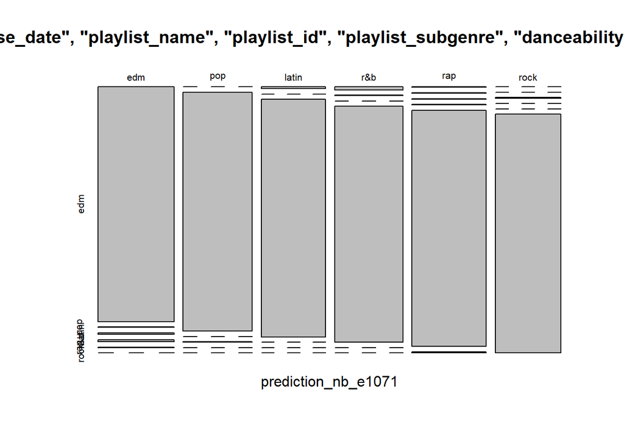

```r
plot(table(prediction_nb_e1071, spotify_data_test[, c("track_id","track_name",
                                                      "track_artist","track_popularity",
                                                      "track_album_id",
                                                      "track_album_name","track_album_release_date",
                                                      "playlist_name","playlist_id","playlist_subgenre",
                                                      "danceability",
                                                      "energy","key","loudness","mode",
                                                      "speechiness",
                                                      "acousticness", "instrumentalness",
                                                      "liveness", "valence",
                                                      "tempo", "duration_ms","playlist_genre")]$playlist_genre))
```